# Dealing Catagorical Data

Managerial Statistics - ECON 730

## R Packages Used In This Lecture

```r
if (!require("tidyverse")) install.packages("tidyverse")
suppressMessages(library(tidyverse))

if (!require("Rmisc")) install.packages("Rmisc")
suppressMessages(library(Rmisc))

if (!require("psych")) install.packages("psych")
suppressMessages(library(psych))

if (!require("foreign")) install.packages("foreign")
suppressMessages(library(foreign))

if (!require("multcomp")) install.packages("multcomp")
suppressMessages(library(multcomp))
```

## Dealing Catagorical Data

## Types of Variables

- Continuous variables
  - Can be any number, positive or negative
  - **Examples:** age in years, weight
- Categorical variables
  - Information that can be sorted into categories
  - Types of categorical variables – ordinal, nominal and dichotomous (binary)

## Categorical Variables

- **Ordinal variable** — a categorical variable with some intrinsic order or numeric value
  - Example: Agreement (strongly disagree, disagree, neutral, agree, strongly agree)
- **Nominal variable** – a categorical variable without an intrinsic order
  - Example: Favorite pet (dog, cat, fish, snake)
- **Dichotomous** (or binary) variables – a categorical variable with only 2 levels of categories
  - Example: An answer to a yes or no question

## Indicator Variables

- Categorical data is represented in regression analysis using a set of indicator, or dummy, variables.
- An indicator, or dummy, variable is a variable that can take on only 2 possible values: 0 or 1 \[D = \left\{ \begin{array}{l} 1\quad {\rm{if}}\;{\rm{an\;observation\;is\; in\; a\; given\; catagory}}\\ {\rm{0}}\quad {\rm{otherwise}} \end{array} \right.\]
- We need one less dummy variable than categories to represent all possible cases.
- The category “left out” is the reference category

## Interpreting Dummy Variables (Part 1)

- Regression with only a dummy variable. Let \(D\) be a dummy variable.
- \(\hat y = {{\hat \beta }_0} + {{\hat \beta }_1}D\)

\[\hat y = \left\{ \begin{array}{l} {{\hat \beta }_0} + {{\hat \beta }_1}\quad D = 1\\ {{\hat \beta }_0}\quad D = 0 \end{array} \right.\]

## Interpreting Dummy Variables (Part 2)

- Regression with a dummy variable and a continuous variable. Let \(D\) be a dummy variable and \(X\) be a continuous variable.
- \(\hat y = {{\hat \beta }_0} + {{\hat \beta }_1}D + {{\hat \beta }_2}X\)

\[\hat y = \left\{ \begin{array}{l} \left( {{{\hat \beta }_0} + {{\hat \beta }_1}} \right) + {{\hat \beta }_2}X\quad D = 1\\ {{\hat \beta }_0} + {{\hat \beta }_2}X\quad D = 0 \end{array} \right.\]

## Interpreting Dummy Variables (Part 3)

- Regression with a dummy variable and a continuous variable and a slope dummy. Let \(D\) be a dummy variable and \(X\) be a continuous variable.
- \(\hat y = {{\hat \beta }_0} + {{\hat \beta }_1}D + {{\hat \beta }_2}X + {{\hat \beta }_3}DX\)

\[\hat y = \left\{ \begin{array}{l} \left( {{{\hat \beta }_0} + {{\hat \beta }_1}} \right) + \left( {{{\hat \beta }_2} + {{\hat \beta }_3}} \right)X\quad D = 1\\ {{\hat \beta }_0} + {{\hat \beta }_2}X\quad D = 0 \end{array} \right.\]

## Detecting Catagorical Effects

## Three Types of Catagorical Effects

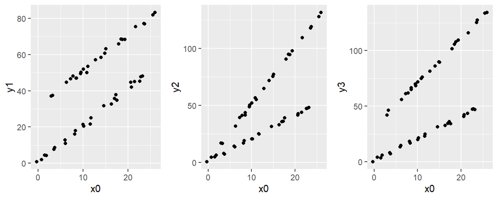

## Factorized Scatorplot

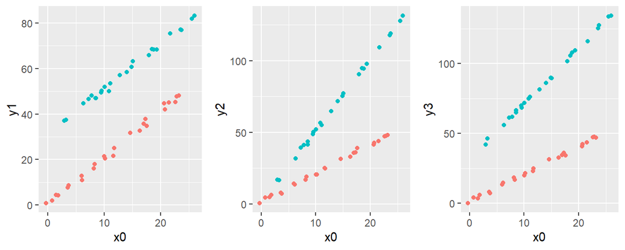

## A more Realistic Example

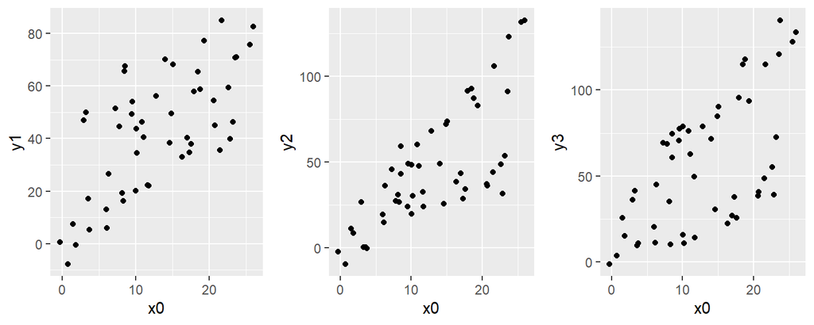

## Add Factor Seperation and Regression Lines

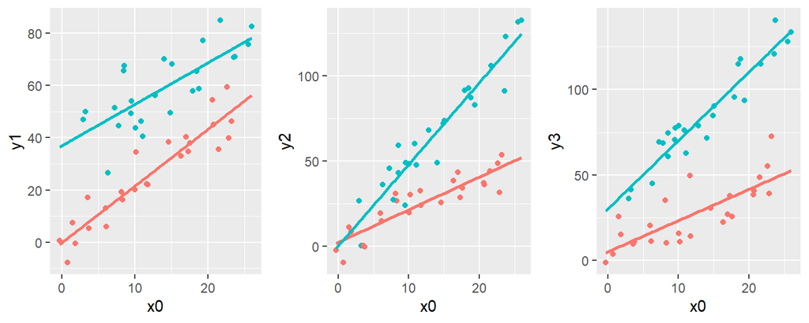

## Class Case: California Strawberries Case

## Case Background: California Strawberries Case

- Susan Lee is the CEO of California Strawberries
- The company has two truck loading systems.
- One in Bakersfield. The other in Monterrey.
- Question: Which system is the quickest?

## Load and Examen the Data

```r
packing <- read.csv("data/california.csv")
head(packing)
```

```
  Time Boxes Plant Plant_Name
1  102   175     0   Monterey
2   69   110     0   Monterey
3  133   225     0   Monterey
4   37    57     0   Monterey
5   28    47     0   Monterey
6  124   217     0   Monterey
```

```r
table(packing$Plant_Name)
```

```
Bakerfield   Monterey
        15         15
```

## Scatterplot of Time vs. Number of Boxes

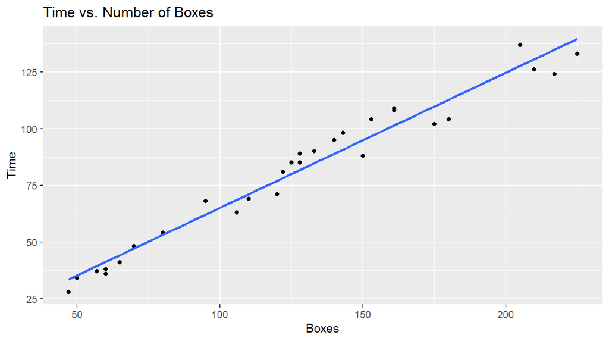

```r
packing %>% ggplot(aes(x=Boxes,y=Time)) +
  geom_point() +
  geom_smooth(method=lm, se=FALSE, fullrange=TRUE) +
  ggtitle("Time vs. Number of Boxes")
```

## Residules from Simple Linear Model

```r
packing.lm01 <- lm(Time ~ Boxes, data = packing)

packing.lm01.res <- resid(packing.lm01)
```

## Residual plot from Simple Linear Model

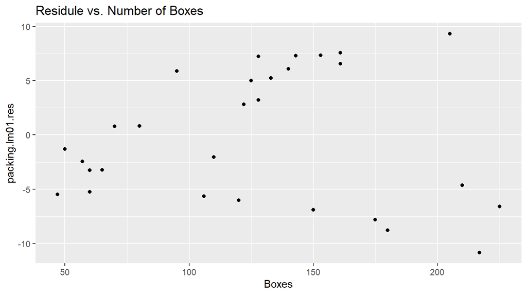

```r
packing %>% ggplot(aes(x=Boxes,y=packing.lm01.res)) +
  geom_point() +
  ggtitle("Residule vs. Number of Boxes")
```

## Color the Residules by Plant

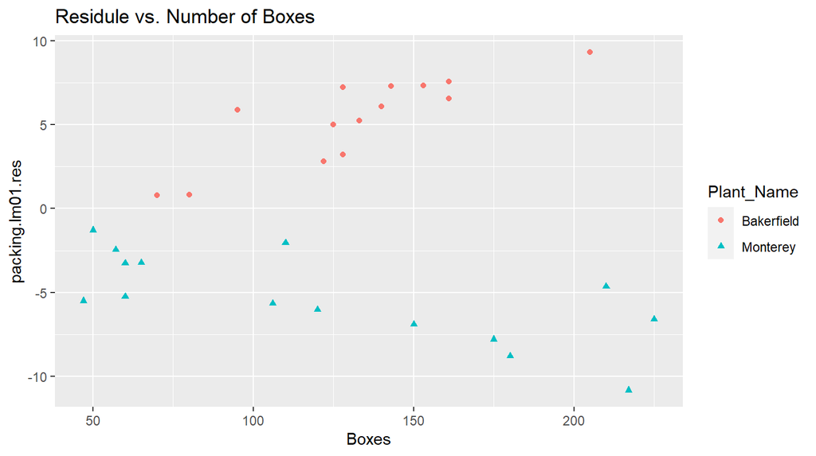

```r
packing %>% ggplot(aes(x=Boxes,y=packing.lm01.res, shape=Plant_Name, color=Plant_Name)) +
  geom_point() +
  ggtitle("Residule vs. Number of Boxes")
```

## Factorized Scatterplot of Time vs. Number of Boxes

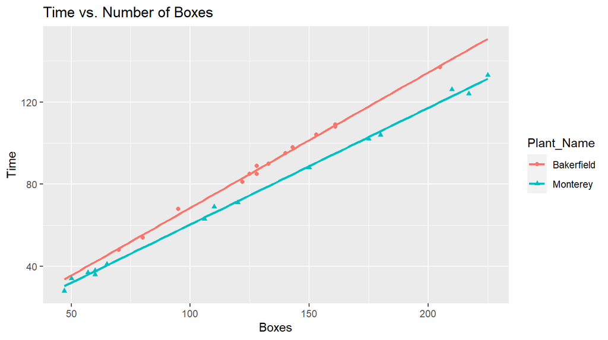

```r
packing %>% ggplot(aes(x=Boxes,y=Time, shape=Plant_Name, color=Plant_Name)) +
  geom_point() +
  geom_smooth(method=lm, se=FALSE, fullrange=TRUE) +
  ggtitle("Time vs. Number of Boxes")
```

## Develop a Model Catagorical Data

## Prepairing the Data

```r
packing$Plant_ <- as.factor(packing$Plant_Name)
levels(packing$Plant_)
```

```
[1] "Bakerfield" "Monterey"
```

## Linear Model model with Catagorical Data

```r
packing.lm02 <- lm(Time ~ Boxes + Plant_ +Plant_:Boxes, data=packing)
summary(packing.lm02)
```

```
Call:
lm(formula = Time ~ Boxes + Plant_ + Plant_:Boxes, data = packing)

Residuals:
    Min      1Q  Median      3Q     Max
-2.7926 -0.9042 -0.0740  0.9392  3.1816

Coefficients:
                     Estimate Std. Error t value Pr(>|t|)
(Intercept)           2.62239    1.81077   1.448    0.160
Boxes                 0.65854    0.01339  49.174  < 2e-16 ***
Plant_Monterey        0.97139    2.04027   0.476    0.638
Boxes:Plant_Monterey -0.09080    0.01503  -6.041 2.22e-06 ***
---
Signif. codes:  0 '***' 0.001 '**' 0.01 '*' 0.05 '.' 0.1 ' ' 1

Residual standard error: 1.682 on 26 degrees of freedom
Multiple R-squared:  0.9974,    Adjusted R-squared:  0.9971
F-statistic:  3341 on 3 and 26 DF,  p-value: < 2.2e-16
```

## Actual vs. Fitted Plots for the Two Models

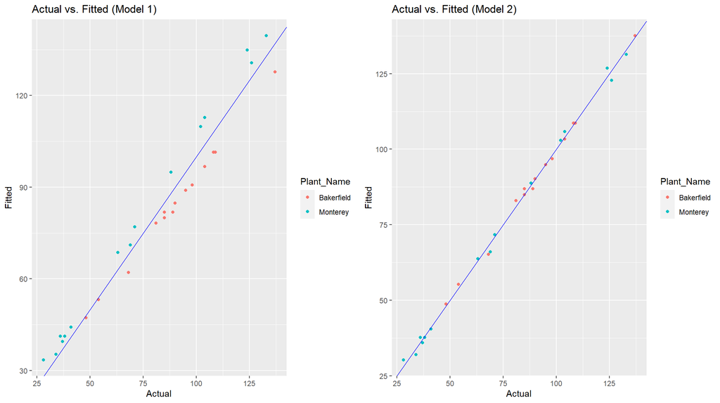

## Finalize the Model

```
Call:
lm(formula = Time ~ Boxes + Plant_:Boxes, data = packing)

Residuals:
    Min      1Q  Median      3Q     Max
-2.8746 -1.0690 -0.1305  1.0559  3.1088

Coefficients:
                      Estimate Std. Error t value Pr(>|t|)
(Intercept)           3.387529   0.822340   4.119 0.000322 ***
Boxes                 0.653046   0.006699  97.478  < 2e-16 ***
Boxes:Plant_Monterey -0.083981   0.004478 -18.754  < 2e-16 ***
---
Signif. codes:  0 '***' 0.001 '**' 0.01 '*' 0.05 '.' 0.1 ' ' 1

Residual standard error: 1.658 on 27 degrees of freedom
Multiple R-squared:  0.9974,    Adjusted R-squared:  0.9972
F-statistic:  5160 on 2 and 27 DF,  p-value: < 2.2e-16
```

## Actual vs. Fitted Plots for the Two Models

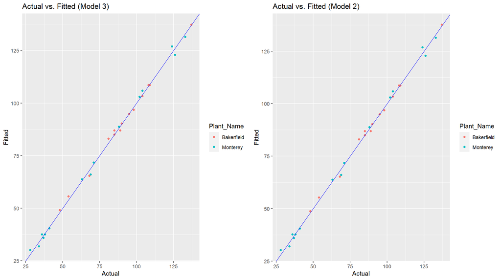

## Interperating the model

- Bakersfield

```r
confint(packing.lm03)
```

```
                           2.5 %      97.5 %
(Intercept)           1.70022677  5.07483115
Boxes                 0.63929982  0.66679194
Boxes:Plant_Monterey -0.09316944 -0.07479264
```

- Monterrey

```r
packing.monterry <- glht(packing.lm03 , linfct = c("Boxes + Boxes:Plant_Monterey = 0"))

confint(packing.monterry)
```

```
     Simultaneous Confidence Intervals

Fit: lm(formula = Time ~ Boxes + Plant_:Boxes, data = packing)

Quantile = 2.0518
95% family-wise confidence level


Linear Hypotheses:
                                  Estimate lwr    upr
Boxes + Boxes:Plant_Monterey == 0 0.5691   0.5565 0.5817
```